# Comprehensive analysis of demographic data on members of the US armed forces, including gender, race, and rank

2023-03-01

```r
glimpse(military)
```

```
## Rows: 1,414,593
## Columns: 6
## $ grade  <fct> officer, officer, officer, officer, officer, officer, officer, …
## $ branch <fct> army, army, army, army, army, army, army, army, army, army, arm…
## $ gender <fct> male, male, male, male, male, male, male, male, male, male, mal…
## $ race   <fct> ami/aln, ami/aln, ami/aln, ami/aln, ami/aln, ami/aln, ami/aln, …
## $ hisp   <lgl> TRUE, TRUE, TRUE, TRUE, TRUE, TRUE, TRUE, TRUE, TRUE, FALSE, FA…
## $ rank   <int> 2, 2, 5, 5, 5, 5, 5, 7, 10, 2, 2, 2, 2, 2, 2, 2, 2, 2, 2, 2, 2,…
```

### What is it?

This dataset contains demographic information on every member of the US armed forces including gender, race, and rank. From our understanding and research this data was collected by the Department of Defense and it seems as though it was required for all active member to participate.

### Where does it come from?

It comes from The Department of Defense and retrieved February 20, 2012.

### Description of each variable?

Grade : The status of the service member as enlisted officer or warrant officer. Branch : The branch of the armed forces: air force, army, marine corps, navy. Gender : Whether the service member is female or male. Race : The race identified by the service member: ami/aln (american indian/alaskan native), asian, black, multi (multi-ethnic), p/i (pacific islander), unk (unknown), or white. Hisp : Whether a service member identifies with being hispanic (TRUE) or not (FALSE). Rank : The numeric rank of the service member (higher number indicates higher rank).

### Types of variables?

The variables are categorical nominal expect for the rank which is a numerical discrete variable.

### What kind of sampling strategy was used to obtain the data?

It is a population sampling and a prospective observational study.

### Histograms

These histograms display the density of service members in each rank. The second one displays a break down of the density of service member in each rank by gender.

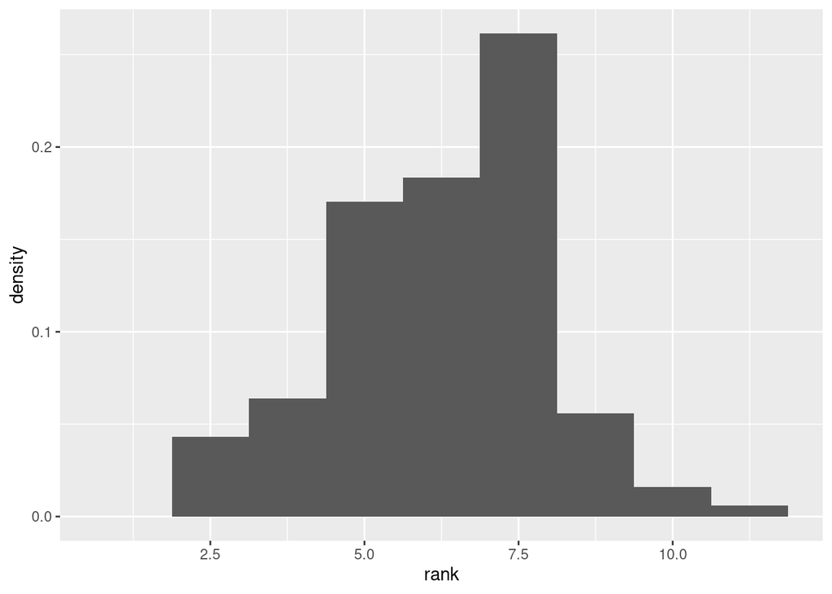

```r
female <- military %>%
  filter(gender == "female")

male <- military %>%
  filter(gender == "male")

officer <- military %>%
  filter(grade == "officer")

warrent <- military %>%
  filter(grade == "warrant")


#histograms
ggplot(data=military,aes(x=rank)) +
  geom_histogram(aes(y = after_stat(density)),
                 position="identity", bins = 9)
```

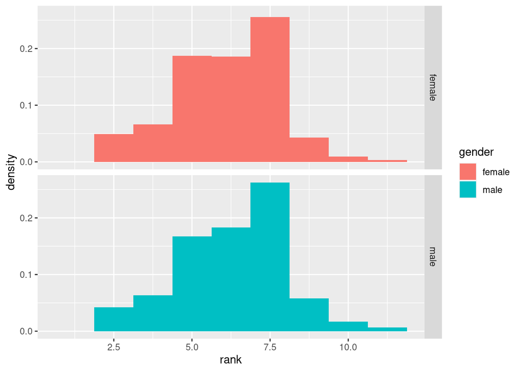

```r
ggplot(data=military,aes(x=rank,fill=gender)) +
  geom_histogram(aes(y = after_stat(density)),
                 position="identity", bins = 9) +
  facet_grid(rows = vars(gender))
```

### Box Plots

These box plots show the breakdown of women’s and men’s races and ranks in the Department of Defense.

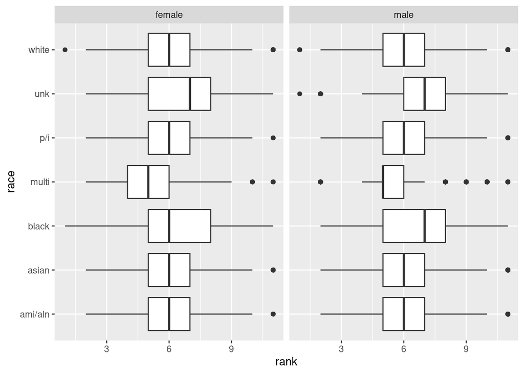

```r
#box plot

ggplot(data=military,aes(x=rank,y=race)) +
  geom_boxplot() +
  facet_grid(col = vars(gender))
```

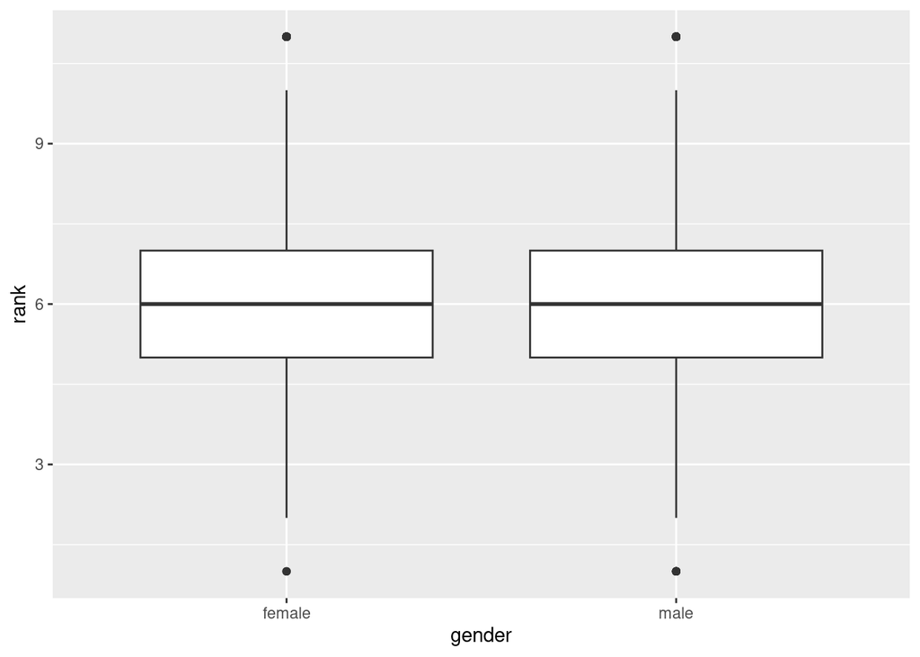

```r
ggplot(military, aes(x=gender, y=rank)) +
  geom_boxplot()
```

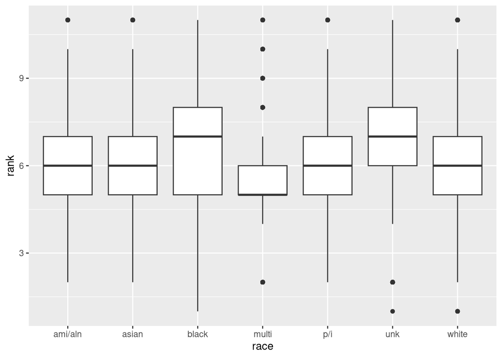

```r
ggplot(military, aes(x=race, y=rank)) +
  geom_boxplot()
```

```r
table(military %>% select(race,rank))
```

```
##          rank
## race           1      2      3      4      5      6      7      8      9     10
##   ami/aln      0   1379      0   2142   5570   6284   5202   2211    898    236
##   asian        0   2645      0   3711  10546  12695  10878   6882   3312    858
##   black        1  11526      1  15949  43439  49635  49707  37869  23423   7051
##   multi        0   3003      0   3430   8110   5251   3924   1495    658    132
##   p/i          0    543      0    690   2392   2155   1841    696    262     80
##   unk          1   2384      0   3996  10055  10804  16724  15347   8969   2257
##   white        7  54679     37  83098 220958 237766 191044 118752  61003  17479
##          rank
## race          11
##   ami/aln     62
##   asian      208
##   black     2532
##   multi       51
##   p/i         44
##   unk        732
##   white     6892
```

### Questions

1. At what point in their careers do minority service members not make rank?
2. What percentage of total females and total males make it to each rank?

### Hypothesis 1: Chi-Squared for two way table

H0: There is no statistically significant difference between the probability of an asian identifying military member making rank from rank 6 to rank 7 then that of a white identifying member. chi-squared = df

HA: There is a statistically significant difference between the probability of an asian identifying military member making rank from rank 6 to rank 7 then that of a white identifying member. chi-squared < df

df = 1 n = 452383

Almost all of the conditions required for this test are met. This means that we are assuming that there is a random sample being taken. This assumption is not being met. We are also assuming that the cell frequencies are at least 5 which is true.

```r
o_a6 <- 12695
o_a7 <- 10878
o_w6 <- 237766
o_w7 <- 191044
asian_total <- 23575
white_total <- 428810
six_total <- 250461
seven_total <- 201922
total <- 452383
df <- 1

E_a6 <- asian_total * six_total / total
E_a7 <- asian_total * seven_total / total
E_w6 <- white_total * six_total / total
E_w7 <- white_total * seven_total / total


x_a6 <- (o_a6 - E_a6)^2 / E_a6
x_a7 <- (o_a7 - E_a7)^2 / E_a7
x_w6 <- (o_w6 - E_w6)^2 / E_w6
x_w7 <- (o_w7 - E_w7)^2 / E_w7

x_2 <- x_a6 + x_a7 + x_w6 + x_w7
p_value <- 1-pchisq(x_2, df)
p_value
```

```
## [1] 1.646316e-06
```

### Hypothesis 2: Chi-Squared for two way table

H0: There is no statistically significant difference between the probability of an female identifying military member making rank from rank 8 to rank 9 then that of a male identifying member. chi-squared = df

HA: There is a statistically significant difference between the probability of an female identifying military member making rank from rank 8 to rank 9 then that of a male identifying member. chi-squared < df

df = 1 n = 281777

Almost all of the conditions required for this test are met. This means that we are assuming that there is a random sample being taken. This assumption is not being met. We are also assuming that the cell frequencies are at least 5 which is true.

```r
o_f8 <- 23806
o_f9 <- 10949
o_m8 <- 159446
o_m9 <- 87576

female_total <- 34755
male_total <- 247022
eight_total <- 183252
nine_total <- 98525
total <- 281777
df <- 1

E_f8 <- female_total * eight_total / total
E_f9 <- female_total * nine_total / total
E_m8 <- male_total * eight_total / total
E_m9 <- male_total * nine_total / total

x_f8 <- (o_f8 - E_f8)^2 / E_f8
x_f9 <- (o_f9 - E_f9)^2 / E_f9
x_m8 <- (o_m8 - E_m8)^2 / E_m8
x_m9 <- (o_m9 - E_m9)^2 / E_m9

x_2 <- x_f8 + x_f9 + x_m8 + x_m9
x_2
```

```
## [1] 208.9828
```

```r
p_value <- 1-pchisq(x_2, df)
p_value
```

```
## [1] 0
```

Based on the given analysis, the results suggest that there is a statistically significant difference in the probability of a female identifying military member making rank from rank 8 to rank 9 compared to that of a male identifying member. The p-value of less than 0.05 indicates that the observed difference in rank attainment between female and male identifying military members is unlikely to occur by chance. These results support the alternative hypothesis (HA) that there is a statistically significant difference in rank attainment between female and male identifying military members. This finding suggests that female identifying military members are either more likely or less likely to make rank from rank 8 to rank 9 compared to their male identifying counterparts. This could be due to various factors such as gender discrimination or differences in opportunities for females in the military. However, it is important to note that the analysis does not provide any information on the reasons for the observed differences.

Based on the data collection method, there are some implicit biases that can impact the accuracy of our conclusion. As this data was collected using a reporting system, there is a possibility that some members chose not to report, or reported incorrectly. Additionally, there is a possibility for certain demographic groups to have chosen not to report, or reported incorrectly, more than others, which would impact the data and create biases that we can’t avoid. This creates a measurement error in which there is a difference in our measured quantity and the true value.